# dbscan

Asignaciones incorrectas: Es posible que algunas muestras estén asignadas incorrectamente a clústeres que no reflejan su verdadera pertenencia. Esto puede deberse a una selección inadecuada de los parámetros del algoritmo DBSCAN (epsilon y min_samples) o a la naturaleza intrínseca de los datos.

Distribución no densa o heterogénea de los datos: La distribución de los datos puede ser tan dispersa o heterogénea que el algoritmo DBSCAN no es capaz de encontrar estructuras significativas de clústeres.

Falta de separación entre clústeres: Los clústeres pueden estar tan cerca entre sí que DBSCAN no puede distinguir claramente entre ellos, lo que resulta en una mala calidad del agrupamiento.

un coeficiente de silueta tan bajo sugiere que el algoritmo DBSCAN no ha logrado encontrar una estructura de clústeres clara y coherente en los datos. Es posible que necesites ajustar los parámetros del algoritmo, explorar diferentes técnicas de agrupamiento o considerar la posibilidad de que los datos no tengan una estructura de clústeres clara y definida.

```python
X = df1[['transacciones','edad','genero','valor_mvto','cant_productos']]
```

```python
scaler = StandardScaler()
X_scaled = scaler.fit_transform(X)
```

```python
# Aplicar DBSCAN
dbscan = DBSCAN(eps=0.1, min_samples=5)  # Puedes ajustar eps y min_samples según tus necesidades
clusters = dbscan.fit_predict(X_scaled)
print(clusters)
```

```
[ 0 -1 -1 ...  1  1 21]
```

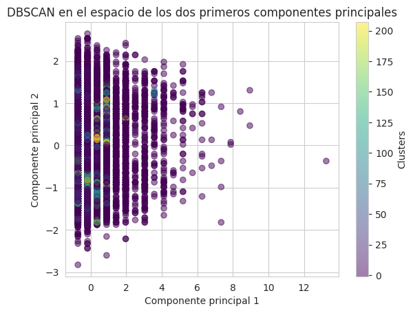

```python
# Visualizar los resultados
#plt.scatter(X_scaled[:,0], X_scaled[:,1], c=clusters, cmap='viridis')
#plt.xlabel('Feature 1')
#plt.ylabel('Feature 2')
#plt.title('DBSCAN Clustering')
#plt.colorbar(label='Cluster')
#plt.show()


# Visualizar los resultados de DBSCAN
plt.scatter(X_scaled[:, 0], X_scaled[:, 1], c=clusters, cmap='viridis', alpha=0.5)
plt.xlabel('Componente principal 1')
plt.ylabel('Componente principal 2')
plt.title('DBSCAN en el espacio de los dos primeros componentes principales')
plt.colorbar(label='Clusters')
plt.grid(True)
plt.show()
```

```python
# Calcula el coeficiente de silueta
silhouette_avg = silhouette_score(X_scaled,clusters)
print("Coeficiente de Silueta:", silhouette_avg)
```

```
Coeficiente de Silueta: -0.40310872249607654
```

```python
dfo= df
```

```python
columns_for_pca = ['transacciones','edad','genero','valor_mvto','cant_productos']
```

```python
x2 = dfo[columns_for_pca]
```

```python
x2
```

| SK_CLIENTE | transacciones | edad | genero | valor_mvto | cant_productos |
| --- | --- | --- | --- | --- | --- |
| 68937 | 1 | 80.0 | 1 | 600000.0 | 1 |
| 83597 | 4 | 49.0 | 1 | 119928.0 | 1 |
| 86570 | 6 | 63.0 | 2 | 118807.0 | 1 |
| 197716 | 1 | 24.0 | 1 | 3000.0 | 1 |
| 204833 | 2 | 56.0 | 2 | 76061.0 | 1 |
| ... | ... | ... | ... | ... | ... |
| 4410983 | 4 | 82.0 | 2 | 349481.0 | 1 |
| 4411791 | 2 | 42.0 | 2 | 189758.0 | 1 |
| 4412445 | 1 | 49.0 | 1 | 20000.0 | 1 |
| 4415269 | 1 | 32.0 | 1 | 35500.0 | 1 |
| 4421550 | 1 | 32.0 | 2 | 205000.0 | 1 |

12772 rows × 5 columns

```python
scaler = StandardScaler()
X_scaled = scaler.fit_transform(x2)
```

```python
# Aplicar PCA
pca = PCA(n_components=4)  # Puedes ajustar el número de componentes principales según tus necesidades
X_pca = pca.fit_transform(X_scaled)
```

```python
pca_df = pd.DataFrame(data=X_pca, columns=['Componente principal 1', 'Componente principal 2','Componente principal 3','Componente principal 4'])
```

```python
print("Varianza explicada por cada componente:")
print(pca.explained_variance_ratio_)
```

```
Varianza explicada por cada componente:
[0.26368942 0.21427666 0.1967398  0.16771738]
```

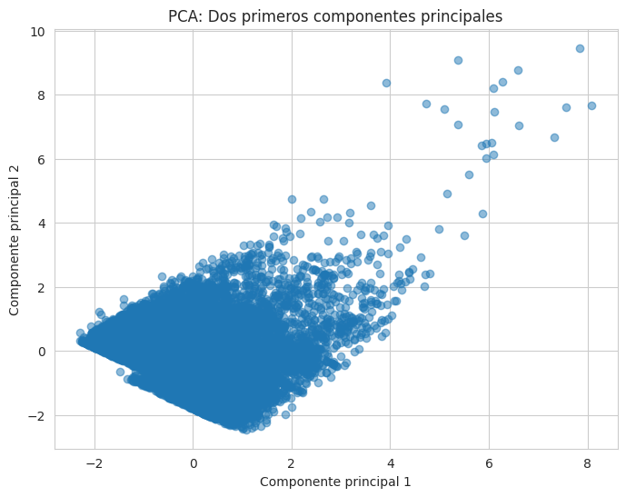

```python
# Graficar los datos en el espacio de los dos primeros componentes principales
plt.figure(figsize=(8, 6))
plt.scatter(pca_df['Componente principal 1'], pca_df['Componente principal 2'], alpha=0.5)
plt.xlabel('Componente principal 1')
plt.ylabel('Componente principal 2')
plt.title('PCA: Dos primeros componentes principales')
plt.grid(True)
plt.show()
```

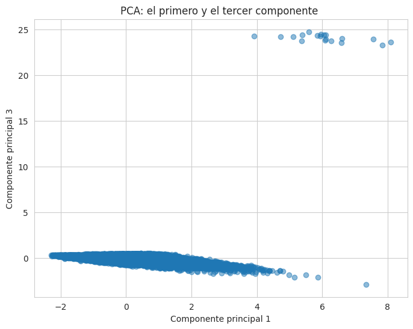

```python
# Graficar los datos en el espacio de los dos primeros componentes principales
plt.figure(figsize=(8, 6))
plt.scatter(pca_df['Componente principal 1'], pca_df['Componente principal 3'], alpha=0.5)
plt.xlabel('Componente principal 1')
plt.ylabel('Componente principal 3')
plt.title('PCA: el primero y el tercer componente ')
plt.grid(True)
plt.show()
```

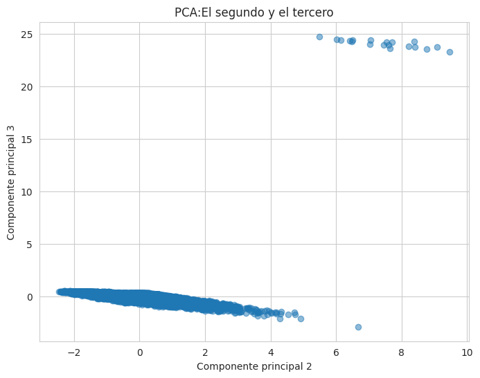

```python
# Graficar los datos en el espacio de los dos primeros componentes principales
plt.figure(figsize=(8, 6))
plt.scatter(pca_df['Componente principal 2'], pca_df['Componente principal 3'], alpha=0.5)
plt.xlabel('Componente principal 2')
plt.ylabel('Componente principal 3')
plt.title('PCA:El segundo y el tercero')
plt.grid(True)
plt.show()
```

```python
k = 4  # Por ejemplo, seleccionamos los cuatro primeros componentes principales
selected_components = pca.components_[:k]
```

```python
# Proyectar los datos originales en el espacio de los k componentes principales
X_projected = X_scaled.dot(selected_components.T)
```

```python
# Definir los parámetros a ajustar
param_grid = {'eps': [0.1, 0.2, 0.3, 0.4, 0.5],
              'min_samples': [5, 10, 20, 50, 100]}
```

```python
# Función de puntuación personalizada
def silhouette_scorer(estimator, X_projected):
    labels = estimator.fit_predict(X_projected)
    return silhouette_score(X_projected, labels)
```

```python
dbscan = DBSCAN()
```

```python
grid_search = GridSearchCV(dbscan, param_grid, scoring=silhouette_scorer)
grid_search.fit(X_projected)
```

[output not shown]

[output cut: 341 more lines]

[output not shown]

```
GridSearchCV(estimator=DBSCAN(),
             param_grid={'eps': [0.1, 0.2, 0.3, 0.4, 0.5],
                         'min_samples': [5, 10, 20, 50, 100]},
             scoring=<function silhouette_scorer at 0x7d7c804e4820>)
```

```python
# Imprimir los mejores parámetros y el coeficiente de silueta
print("Mejores parámetros:", grid_search.best_params_)
print("Coeficiente de silueta:", silhouette_score(Y, grid_search.best_estimator_.labels_))
```

```
Mejores parámetros: {'eps': 0.5, 'min_samples': 50}
Coeficiente de silueta: 0.21336869975915854
```

```python
# Aplicar DBSCAN en el espacio de los componentes principales
dbscan = DBSCAN(eps=0.5, min_samples=50)
clusters = dbscan.fit_predict(X_projected)
```

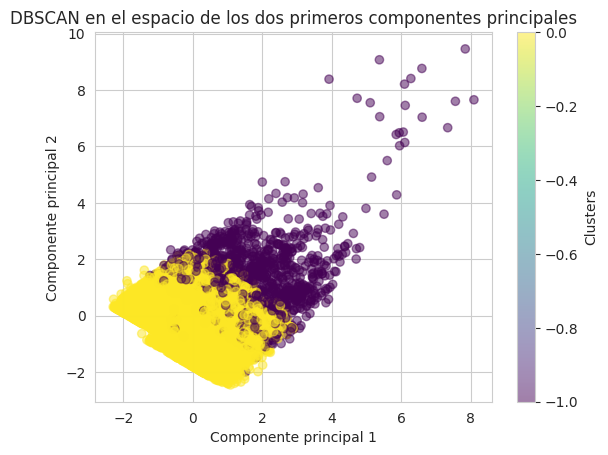

```python
# Visualizar los resultados de DBSCAN
plt.scatter(X_projected[:, 0], X_projected[:, 1], c=clusters, cmap='viridis', alpha=0.5)
plt.xlabel('Componente principal 1')
plt.ylabel('Componente principal 2')
plt.title('DBSCAN en el espacio de los dos primeros componentes principales')
plt.colorbar(label='Clusters')
plt.grid(True)
plt.show()
```

```python
# Calcula el coeficiente de silueta
silhouette_avg = silhouette_score(X_projected, clusters)
print("Coeficiente de Silueta:", silhouette_avg)
```

```
Coeficiente de Silueta: 0.43211090185663636
```

Alto grado de homogeneidad y cohesión: Las muestras dentro de cada clúster son más similares entre sí que con las muestras en otros clústeres, lo que sugiere una alta homogeneidad y cohesión dentro de los clústeres.

```python
df2= df
```

```python
# Índice de Davies-Bouldin
db_score = davies_bouldin_score(X_projected, clusters)
print("Índice de Davies-Bouldin:", db_score)
```

```
Índice de Davies-Bouldin: 1.4446590340864747
```

El Índice de Davies-Bouldin (DB) es una métrica de validación interna que se utiliza para evaluar la calidad de un agrupamiento. Cuanto menor sea el valor del índice de Davies-Bouldin, mejor será el agrupamiento.

El resultado obtenido, 1.4446590340864747, indica que el agrupamiento tiene un valor medio de Davies-Bouldin. La interpretación de este valor depende del contexto y de la comparación con otros resultados. Aquí hay algunas interpretaciones generales:

Si el índice de Davies-Bouldin es cercano a 0, significa que los clústeres están bien separados y tienen una buena cohesión interna. Este es el escenario ideal.

Si el índice de Davies-Bouldin es mayor que 1, indica que los clústeres no están bien separados y pueden estar superpuestos. Un valor alto sugiere que el agrupamiento no es tan bueno y que los clústeres pueden no ser representativos o relevantes.

Un valor de 1.44 indica que el agrupamiento tiene una calidad media en términos de separación entre clústeres y cohesión interna.

```python
# Criterio de Calinski-Harabasz
ch_score = calinski_harabasz_score(X_projected, clusters)
print("Criterio de Calinski-Harabasz:", ch_score)
```

```
Criterio de Calinski-Harabasz: 2258.8312242131137
```

El Criterio de Calinski-Harabasz (CH) es una métrica de validación interna que se utiliza para evaluar la calidad de un agrupamiento. Cuanto mayor sea el valor del criterio de Calinski-Harabasz, mejor será el agrupamiento.

El resultado obtenido, 2258.8312242131137, indica una puntuación bastante alta en el criterio de Calinski-Harabasz. La interpretación de este valor es la siguiente:

Un valor alto del criterio de Calinski-Harabasz sugiere que los clústeres están bien separados entre sí y tienen una buena cohesión interna. Esto significa que los puntos dentro de cada clúster son similares entre sí y que los clústeres están claramente definidos y separados. un valor de 2258.83 en el criterio de Calinski-Harabasz indica que el agrupamiento tiene una buena calidad en términos de separación entre clústeres y cohesión interna.

```python
# Añadir las etiquetas de clúster al DataFrame original
dfo['cluster'] = clusters
```

```python
dfo
```

| SK_CLIENTE | transacciones | edad | antiguedad | apertura | pais | ocupacion | tipo_vivienda | estado_civil | nivel_estudios | genero | no_personas_a_cargo | valor_mvto | cant_productos | Con_Pareja | Educacion | cluster |
| --- | --- | --- | --- | --- | --- | --- | --- | --- | --- | --- | --- | --- | --- | --- | --- | --- |
| 68937 | 1 | 80.0 | 26.0 | 26.0 | Colombia | Pensionado | Familiar | Casado(a) | Profesional | 1 | 2 | 600000.0 | 1 | 1 | Profesional | 0 |
| 83597 | 4 | 49.0 | 19.0 | 19.0 | Colombia | Fuerzas Militares | Propia | Viudo(a) | Especializacion | 1 | 5 | 119928.0 | 1 | 0 | Postgrado | 0 |
| 86570 | 6 | 63.0 | 25.0 | 5.0 | Colombia | Pensionado | Propia | Soltero(a) | Profesional | 2 | 0 | 118807.0 | 1 | 0 | Profesional | -1 |
| 197716 | 1 | 24.0 | 5.0 | 5.0 | Colombia | Estudiante | Familiar | Soltero(a) | Primaria | 1 | 0 | 3000.0 | 1 | 0 | Academico | 0 |
| 204833 | 2 | 56.0 | 24.0 | 24.0 | Colombia | Empleado | Propia | Casado(a) | Primaria | 2 | 0 | 76061.0 | 1 | 1 | Academico | 0 |
| ... | ... | ... | ... | ... | ... | ... | ... | ... | ... | ... | ... | ... | ... | ... | ... | ... |
| 4410983 | 4 | 82.0 | 26.0 | 26.0 | Colombia | Pensionado | Propia | Casado(a) | Primaria | 2 | 0 | 349481.0 | 1 | 1 | Academico | 0 |
| 4411791 | 2 | 42.0 | 5.0 | 5.0 | Colombia | Fuerzas Militares | Familiar | Casado(a) | Primaria | 2 | 0 | 189758.0 | 1 | 1 | Academico | 0 |
| 4412445 | 1 | 49.0 | 22.0 | 22.0 | Colombia | Pensionado | Propia | Union Libre | Primaria | 1 | 0 | 20000.0 | 1 | 1 | Academico | 0 |
| 4415269 | 1 | 32.0 | 12.0 | 12.0 | Colombia | Fuerzas Militares | Familiar | Soltero(a) | Primaria | 1 | 0 | 35500.0 | 1 | 0 | Academico | 0 |
| 4421550 | 1 | 32.0 | 7.0 | 7.0 | Colombia | Empleado | Familiar | Soltero(a) | Profesional | 2 | 0 | 205000.0 | 1 | 0 | Profesional | 0 |

12772 rows × 16 columns

```python
# Crear un diccionario para almacenar los DataFrames de cada clúster
cluster_datasets = {}

# Iterar sobre cada clúster y extraer los datos correspondientes
for cluster_label in np.unique(clusters):
    cluster_data = df[df['cluster'] == cluster_label]
    cluster_datasets[cluster_label] = cluster_data
```

```python
cluster_datasets
```

[output not shown]

[output cut: 99 more lines]

```python
cluster_label = 0
cluster_data = cluster_datasets[cluster_label]


print(cluster_data.head())
```

```
            transacciones  edad  antiguedad  apertura      pais  \
SK_CLIENTE
68937                   1  80.0        26.0      26.0  Colombia
83597                   4  49.0        19.0      19.0  Colombia
197716                  1  24.0         5.0       5.0  Colombia
204833                  2  56.0        24.0      24.0  Colombia
205535                  1  36.0        13.0      13.0  Colombia

                    ocupacion tipo_vivienda estado_civil   nivel_estudios  \
SK_CLIENTE
68937              Pensionado      Familiar    Casado(a)      Profesional
83597       Fuerzas Militares        Propia     Viudo(a)  Especializacion
197716             Estudiante      Familiar   Soltero(a)         Primaria
204833               Empleado        Propia    Casado(a)         Primaria
205535                Docente     Arrendada    Casado(a)      Profesional

            genero  no_personas_a_cargo  valor_mvto  cant_productos  \
SK_CLIENTE
68937            1                    2    600000.0               1
83597            1                    5    119928.0               1
197716           1                    0      3000.0               1
204833           2                    0     76061.0               1
205535           1                    2    239200.0               1

            Con_Pareja    Educacion  cluster
SK_CLIENTE
68937                1  Profesional        0
83597                0    Postgrado        0
197716               0    Academico        0
204833               1    Academico        0
205535               1  Profesional        0
```

```python
#
cluster_label = -1
cluster_data2 = cluster_datasets[cluster_label]


print(cluster_data2.head())
```

```
            transacciones  edad  antiguedad  apertura      pais   ocupacion  \
SK_CLIENTE
86570                   6  63.0        25.0       5.0  Colombia  Pensionado
214784                  5  62.0         4.0       4.0  Colombia  Pensionado
215177                  5  44.0        17.0      17.0  Colombia  Estudiante
216798                  5  47.0        24.0      20.0  Colombia    Empleado
221893                  8  45.0        15.0      15.0  Colombia    Empleado

           tipo_vivienda estado_civil   nivel_estudios  genero  \
SK_CLIENTE
86570             Propia   Soltero(a)      Profesional       2
214784            Propia  Union Libre      Profesional       1
215177            Propia  Union Libre  Especializacion       2
216798          Familiar    Casado(a)      Profesional       2
221893         Arrendada    Casado(a)  Especializacion       2

            no_personas_a_cargo  valor_mvto  cant_productos  Con_Pareja  \
SK_CLIENTE
86570                         0    118807.0               1           0
214784                        3     85742.0               1           1
215177                        0    231058.0               1           1
216798                        3    571035.0               1           1
221893                        1    463925.0               1           1

              Educacion  cluster
SK_CLIENTE
86570       Profesional       -1
214784      Profesional       -1
215177        Postgrado       -1
216798      Profesional       -1
221893        Postgrado       -1
```